# R Notebook

Farina et al. use the

$$f(t) = \frac{1}{2\pi}
\int_{-\infty}^{\infty} F(\omega) e^{j\omega t}
\mathrm{d}\omega$$

convention for the inverse Fourier transform and the

$$F(\omega) = \int_{-\infty}^{\infty}
f(t) e^{-j\omega t} \mathrm{d}t$$

convention for the forward Fourier transform, corresponding to the “non-unitary formulation of the Fourier-transform in angular frequency” ([wiki](https://en.wikipedia.org/wiki/Fourier_transform#Other_conventions)). So this is the type of Fourier transform we obtain when evaluating equation (23) in their paper.

What do we need to do to convert these expressions to properly scaled time series signals?

Let’s find out.

First, set up the problem, sampling settings, signal to be considered: a Gaussian. (Notice that a *pure sine* is actually a bad choice for a test signal: the analytical Fourier transform has infinite-height Dirac impulses, which makes everything more complicated. Also see [here](https://de.mathworks.com/matlabcentral/answers/15770-scaling-the-fft-and-the-ifft#answer_276312).)

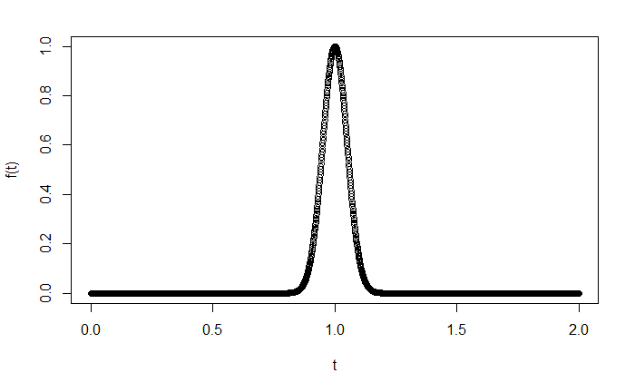

```r
library(semgsim)
Fs <- 1024
NFFT <- 2048
sampling <- semgsim:::create_sampling(Fs, NFFT)
sigma <- 0.05
# Gaussian signal: Fourier transform is Gaussian again, i.e., finite everywhere
f <- function(t) exp(-(t-1)^2 / (2 * sigma^2))
t <- seq(0, NFFT/Fs - 1/Fs, 1/Fs)
plot(t, f(t))
```

Next, we calculate the analytical Fourier transform using the integration formula.

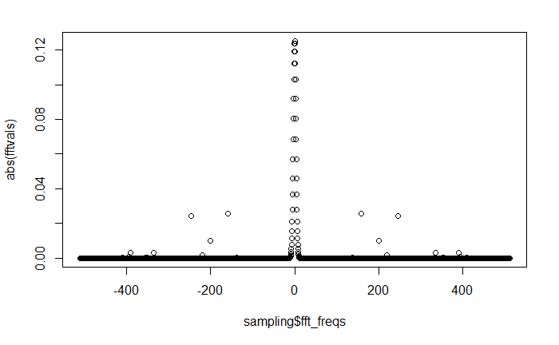

```r
calc_TF_point <- function(ang_freq) {
  real_part <- try(integrate(function(t) Re(f(t) * exp(-1i * ang_freq * t)), -Inf, Inf)$value, silent = TRUE)
  if (class(real_part) == 'try-error') {
    real_part <- 0
  }

  imaginary_part <- try(integrate(function(t) Im(f(t) * exp(-1i * ang_freq * t)), -Inf, Inf)$value, silent = TRUE)
  if (class(imaginary_part) == 'try-error') {
    imaginary_part <- 0
  }

  return(real_part + 1i * imaginary_part)
}
calc_TF <- Vectorize(calc_TF_point, 'ang_freq')

# We only need to calculate half of the FFT values, because for a real signal, the Fourier spectrum is Hermitian
fftvals_half <- calc_TF(sampling$freqs_to_calc * 2 * pi)

# Obtain the remaining samples by mirroring
fftvals <- semgsim:::mirror_hermitian_fft(fftvals_half, sampling)
stopifnot(semgsim:::is_fft_of_real_signal(fftvals, sampling))

# Plot the Fourier spectrum
plot(sampling$fft_freqs, abs(fftvals))
```

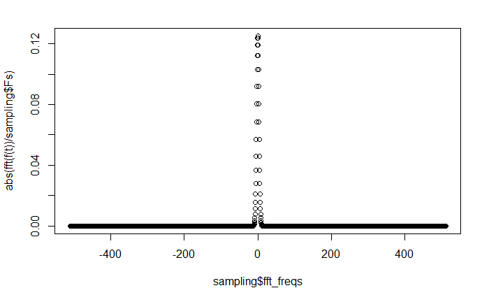

```r
# Compare with the FFT-calculated spectrum
plot(sampling$fft_freqs, abs(fft(f(t)) / sampling$Fs))
```

There are definite errors in the spectrum… are those numerical integration artifacts? I guess so. The exact spectrum should be a Gaussian again, cf. the results of the FFT. Ignoring these errors for now.

Finally, use the inverse FFT (as we do in semgsim) to get the time signals.

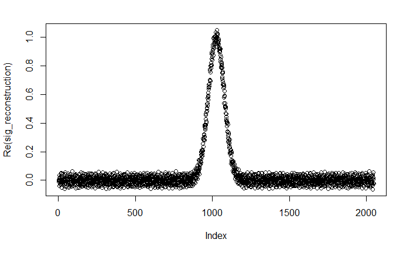

```r
sig_reconstruction <- fft(fftvals, inverse=TRUE) * sampling$Fs / NFFT
plot(Re(sig_reconstruction))
```

I am quite sure this is so noisy because of the artifacts in the spectrum, as discussed above. I am currently mostly concerning with getting the *scaling* of all the transforms right, so I don’t care so much. Apparently, **we need to scale with a factor $F_s / \mathrm{NFFT}$.**